# Metabox 2.0: Tutorial for R Commands

Kwanjeera W

2026-04-10

## HOW TO USE

Here are some alternative ways to use Metabox 2.0:

- [Install as a standard R package](https://github.com/kwanjeeraw/metabox2?tab=readme-ov-file#install-as-a-standard-r-package)
- [Use metabox with Docker](https://github.com/kwanjeeraw/metabox2?tab=readme-ov-file#use-metabox-with-docker)
- [Use metabox via online server](https://github.com/kwanjeeraw/metabox2?tab=readme-ov-file#use-an-online-version-from-our-servers)

## CONTENTS

This tutorial demonstrates how to run Metabox 2.0 as an R package and requires familiarity with R. It walks through five modules. Figure 1 shows the pipeline overview. Follow the script step by step in the sections below.

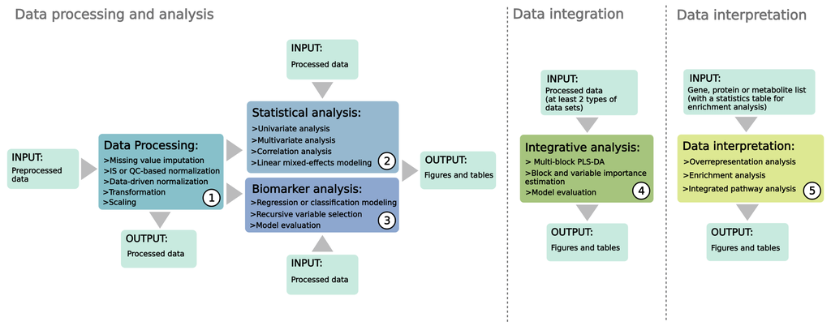

*Figure 1. Overview of Metabox 2.0 containing three key pipelines and five modules*

Go to Section:

- PROJECT INITIALIZATION
- DATA PROCESSING
- STATISTICAL ANALYSIS
- BIOMARKER ANALYSIS
- INTEGRATIVE ANALYSIS
- DATA INTERPRETATION

### PREPARE INPUT DATA

The input dataset should be a CSV table containing metadata columns along with feature variables, as illustrated in Table 1. Samples are in rows, and variables (features) are in columns. Experimental information—such as batch, sample type, and injection order—is required for IS- and QC-based normalization.

**Table 1**. Format of the input dataset. This example table includes metadata (brown), experimental information (blue), and metabolite features.

| Sample | SampleGroup | RunOrder | Batch | SampleType | IS_D3-Alanine | IS_C13-Phenylalanine | L-Alanine | L-Valine | Leucine |
| --- | --- | --- | --- | --- | --- | --- | --- | --- | --- |
| Sample11 | DM | 14 | Batch1 | Sample | 3415100 | 2037269 | 3170319 | 3053960 | 918680 |
| Sample14 | DM | 71 | Batch1 | Sample | 6082869 | 4748038 | 5167928 | 4157701 | 1654664 |
| Sample16 | DM | 19 | Batch2 | Sample | 13975619 | 9542307 | 12652652 | 10157293 | 4233637 |
| Sample20 | KF | 23 | Batch2 | Sample | 14006790 | 9625350 | 7125928 | 3672381 | 525327 |
| Sample23 | KF | 27 | Batch2 | Sample | 6160146 | 4026638 | 3203784 | 2576521 | 816807 |
| Sample25 | KF | 29 | Batch2 | Sample | 11925818 | 10293816 | 7917620 | 5083482 | 2436176 |

## PROJECT INITIALIZATION

### 1. Setup the project:

- For this tutorial, download the [demo dataset](https://github.com/kwanjeeraw/metabox2/blob/main/inst/shiny/www/GCGC_DM_Samples.csv) (GCGC_DM_Samples.csv) and save it to your working directory
- Open R or RStudio, then set the working directory and load the Metabox2 package with the following R command

```
##### INITIALIZATION #####
setwd("/Users/macuser/projectname/") #set the working directory
library(metabox2) #load the package
```

### 2. Load input data

```
input_dat = read_input_data(filename='GCGC_DM_Samples.csv') #load input file
```

### 3. Set Metabox object

Specifying the required arguments for the *set_input_obj* function to setup the Metabox object:

- *inputdata*: dataframe of input data. Samples are in rows and variables/features are in columns.
- *idCol*: column index of the sample ID column. Default is 1.
- *classCol*: column index of the category/factor column (for hypothesis testing and classification) or the response column (for regression).
- *xCol*: column index of the first variable/feature column.

```
input_obj = set_input_obj(inputdata=input_dat, idCol=1, classCol=2, xCol=6) #setup metabox object
head(input_obj$X) #preview the data
```

**Output:** The following output will be printed to the console, along with part of the input dataset. The dataset includes 75 samples across four groups and 91 metabolites, with some missing values.

```
Data summary:
- 75 samples and 91 variables.
- repeated samples = FALSE .
- class/factor with 4 levels.
- 0 negative variables.
- 478 ( 7 % ) missing values.
```

## Module 1-DATA PROCESSING

Key steps in this module include missing value imputation, normalization, transformation, and scaling.

**Table 2**. Summary of normalization, transformation, and scaling in metabolomics.

| Step | Purpose | Correction | Methods |
| --- | --- | --- | --- |
| Normalization | Remove technical bias | Injection variation, batch effects | IS-, QC-based, median/TIC |
| Transformation | Improve data distribution | Skewness, heteroscedasticity | Log, square root, cube root |
| Scaling | Balance variable importance | Dominance of high-intensity metabolites | Pareto scaling, autoscaling, range scaling |

**Note:** In practice, not all steps are required; the choice depends on the data. Users are encouraged to examine their data first.

### *Missing value imputation*

This step replaces missing values using information from the existing data.

Specifying the required arguments for the *impute_missing_data* function:

- *METBObj*: Metabox object.
- *method*: missing value imputation method (options: zero, halfmin, min, mean, median, lod, bpca, ppca, svd, knn, rf, default: median).
- *lod*: numeric value (e.g., LOD or LOQ) for imputing missing values; required for the lod method.
- *removeall*: logical value indicating whether variables with any missing values are removed (TRUE) or retained (FALSE; default).
- *cutoff*: percentage threshold for missing values (1–99; default = FALSE). If FALSE, all missing values are imputed; otherwise, variables exceeding the cutoff are removed.

```
output_imputed = impute_missing_data(METBObj=input_obj, method="rf", removeall=FALSE, cutoff=30)
head(output_imputed$X) #preview imputed data
```

**Output:** A summary of the output will be printed to the console, along with part of the imputed dataset. Try other methods or cutoff values if preferred.

Optional: export the imputed data using the following R command

```
write.csv(data.frame(output_imputed$inputdata[,1:(output_imputed$xCol-1)], output_imputed$X, check.names=FALSE), file='RF_imputed_data.csv', row.names=FALSE)
```

### *Normalization*

This step corrects technical variation using known reference compounds, quality control (QC) samples, or statistical assumptions about the dataset.

#### Try IS-based normalization with CCMN method

Specifying the required arguments for the *normalize_input_data_byqc* function:

- *METBObj*: Metabox object.
- *method*: normalization method (options: ccmn, nomis, ruvrand, serrf, loess, default: nomis).
- *istd*: a column index or a vector of column indices indicating the internal standard(s) (IS) in the METBObj$X dataframe. This parameter is required for IS-based normalization methods (ccmn, nomes, ruvrand).
- *factorCol*: a column index indicating the biological factor of interest in the METBObj$inputdata dataframe.
- *batch*: a column index indicating the batch information in the METBObj$inputdata dataframe. Required for serrf and loess methods. Each batch must contain at least two QC samples.
- *sampleType*: a column index indicating the sample types in the METBObj$inputdata dataframe. Required for serrf and loess methods. Each batch must contain at least two QC samples. Use “qc” for QC samples and “sample” for subject samples.
- *injectionOrder*: a column index indicating the injection (run) order in the METBObj$inputdata dataframe. Required for serrf and loess methods. The injection order must be numeric and unique.

```
output_norm = normalize_input_data_byqc(METBObj=output_imputed, method="ccmn", istd=1:2, factorCol=2)
pcaplot_overview(output_norm, scale=TRUE) #preview normalized data with PCA
```

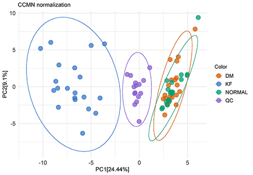

*Figure 2. PCA of CCMN normalized data*

#### Try Data-driven normalization by median

Specifying the required arguments for the *normalize_input_data_bydata* function:

- *METBObj*: Metabox object.
- *method*: normalization method (options: contrast, cubic, eigenms, linear, loess, mean, median, pqn, quantile, sum, vsn, default: median).
- *ref*: a row index or a vector of row indices indicating the reference/control samples in the METBObj$inputdata dataframe. This parameter is required for the pqn method.

```
output_norm = normalize_input_data_bydata(METBObj=output_imputed, method="median") #normalize by median
pcaplot_overview(output_norm, scale=TRUE) #preview normalized data with PCA
```

### *Transformation*

Transformation mainly changes distribution of the data.

#### Try Square root transformation

Specifying the required arguments for the *transform_input_data* function:

- *METBObj*: Metabox object.
- *method*: transformation method (options: cube, glog10, glog2, log10, log2, sqrt, default: sqrt).

```
output_sqrt = transform_input_data(METBObj=output_norm, method="sqrt")
pcaplot_overview(output_sqrt, scale=TRUE) #preview transformed data with PCA
```

### *Scaling*

Scaling adjusts the relative importance of variables (features) so that metabolites with large values do not dominate the analysis, particularly in multivariate analysis.

#### Try Pareto scaling

Specifying the required arguments for the *scale_input_data* function:

- *METBObj*: Metabox object.
- *method*: scaling method (options: auto, level, pareto, power, range, vast, default: pareto).

```
output_pareto = scale_input_data(METBObj=output_norm, method="pareto")
pcaplot_overview(output_pareto, scale=TRUE) #preview scaled data with PCA
```

#### Try observing data with different plots

Metabox 2.0 includes several plotting functions for data visualization, as demonstrated in the following command.

```
pcaplot_overview(output_pareto, classCol=2, shapeCol=4) #PCA plot

boxplot_overview(output_pareto, plotvar=TRUE) #Variable boxplot
boxplot_overview(output_pareto, plotvar=FALSE) #Sample boxplot

rlaplot_overview(output_pareto, classCol=2, dolog = FALSE) #RLA plot

densityplot_overview(output_pareto$X, plotvar=TRUE) #Variable density plot
densityplot_overview(output_pareto$X, plotvar=FALSE) #Sample density plot
```

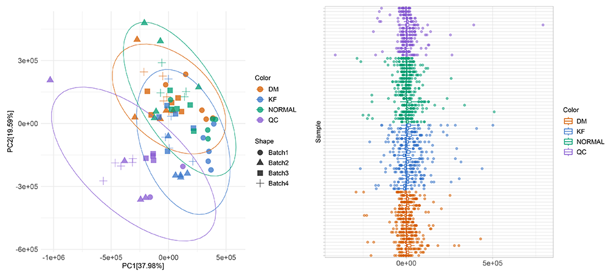

*Figure 3. PCA and RLA plots*

## Module 2-STATISTICAL ANALYSIS

Metabox 2.0 supports both univariate and multivariate analyses.

### *Univariate analysis*

**Table 3**. Summary of univariate statistical methods.

| Type | Pairwise Independent | Pairwise Repeated | ANOVA Independent | ANOVA Repeated | Correlation | Linear Modeling |
| --- | --- | --- | --- | --- | --- | --- |
| Parametric | t.test | t.test (paired) | ANOVA -> posthoc.test | ANOVA -> pairwise.t.test | Pearson | Linear mixed-effect |
| Non-parametric | wilcox.test/mann-whitney | wilcox.test (paired) | kruskal.test -> dunn.test or Scheirer Ray Hare.test -> wilcox.test (2W-ANOVA) | friedman.test -> dunn.test | Spearman | N/A |

Specifying the required arguments for the *univ_analyze* function:

- *METBObj*: Metabox object.
- *var.equal*: a logical variable for pairwise comparisons indicating whether to assume equal variances between groups.
- *ispara*: a logical variable indicating whether to perform a parametric (TRUE) or non-parametric (FALSE; default) test.
- *factor2Col*: a column index of the second factor in the METBObj$inputdata dataframe. This parameter is used for two-way ANOVA.
- *doposthoc*: a logical variable indicating whether to perform post hoc tests for one-way and two-way ANOVA (FALSE; default).

The following commands perform univariate analysis on the demo dataset. A Kruskal–Wallis rank-sum test is applied, as the data include four groups. Users can view plots for L-alanine; change xCol to explore other metabolites.

```
output_univ = univ_analyze(METBObj=output_sqrt, var.equal=FALSE, ispara=FALSE, doposthoc=FALSE)
str(output_univ) #preview statistical results

boxplot_byF1(METBObj=output_sqrt, xCol=3, factorLv1=output_sqrt$Y) #boxplot by a fator
boxplot_byF1F2(METBObj=output_sqrt, xCol=3, factorLv1=output_sqrt$Y, factorLv2=output_sqrt$inputdata$Batch) #boxplot by 2 fators
interactionplot_byF1F2(x_input=output_sqrt$X, xCol=3, factorLv1=output_sqrt$Y, factorLv2=output_sqrt$inputdata$Batch) #interaction plot
```

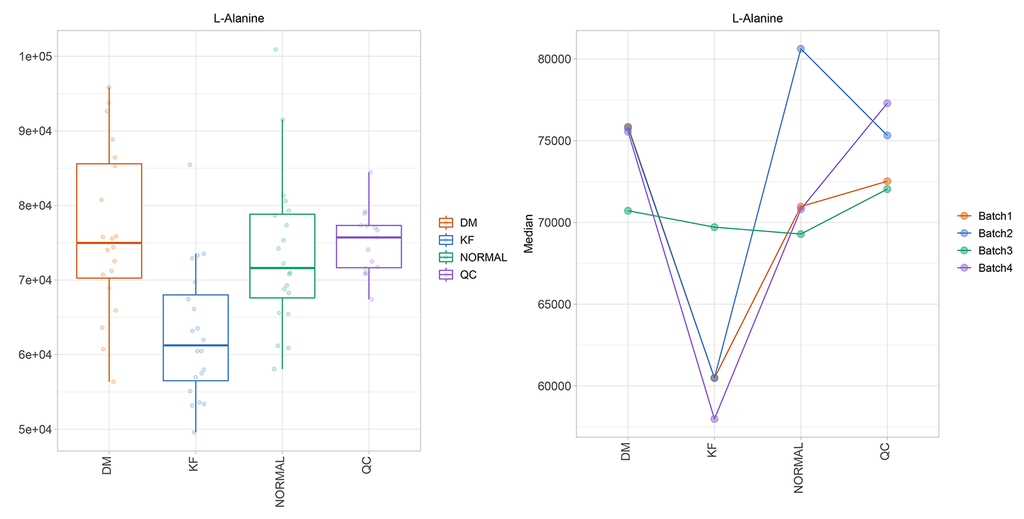

*Figure 4. Boxplot and interaction plot for L-alanine*

### *Correlation analysis*

Specifying the required arguments for the *correlation_analyze* function:

- *METBObj*: Metabox object.
- *y*: a numeric vector, matrix, or dataframe of additional variables (e.g., genes, proteins, or compounds), with samples as row names. If provided, correlations will be calculated between all variables in METBObj$X and y.
- *method*: correlation method (options: pearson or spearman, default: pearson).

```
output_corr = correlation_analyze(METBObj=output_sqrt, method="pearson")
str(output_corr) #preview statistical result
corrplot_heatmap(data.frame(output_corr$corr_data)) #correlation heatmap
```

### *Multivariate analysis*

Specifying the required arguments for the *multiv_analyze* function:

- *METBObj*: Metabox object.
- *method*: multivariate analysis method (options: pca, pls, opls, default: pca).
- *scale*: scaling method for scaleC in ropls::opls(): no centering or scaling (“none”), mean-centering only (“center”, default), mean-centering with Pareto scaling (“pareto”), or mean-centering with autoscaling (“standard”).
- *predI*: number of components (5 for PCA, 1 for OPLS, NA for PLS for autofit).
- *crossvalI*: number of cross-validation segments (default = 3); samples must be ≥ crossvalI.
- *permI*: number of permutations of response labels (default = 20).

#### Try PCA

```
#Do PCA
output_pca = multiv_analyze(METBObj=output_sqrt, method="pca", scale="center")
```

**Output:** The following output will be printed to the console.

```
Performing multivariate analysis ...
PCA
75 samples x 84 variables
center scaling of predictors
      R2X(cum) pre ort
Total    0.836   5   0

 PCA was performed.
```

The following commands to explore outputs from the analysis.

```
#PCA score plot
multiv_scoreplot(METBObj=output_sqrt, score_data=output_pca$score_val, pcx=output_pca$model_summary$R2X[1], pcy=output_pca$model_summary$R2X[2])

#Loading plot
multiv_loadingplot(loading_data=output_pca$loading_val)

#Loding plot of PC1
multiv_loadingplot_bypc(loading_data=output_pca$loading_val, pc=1)
```

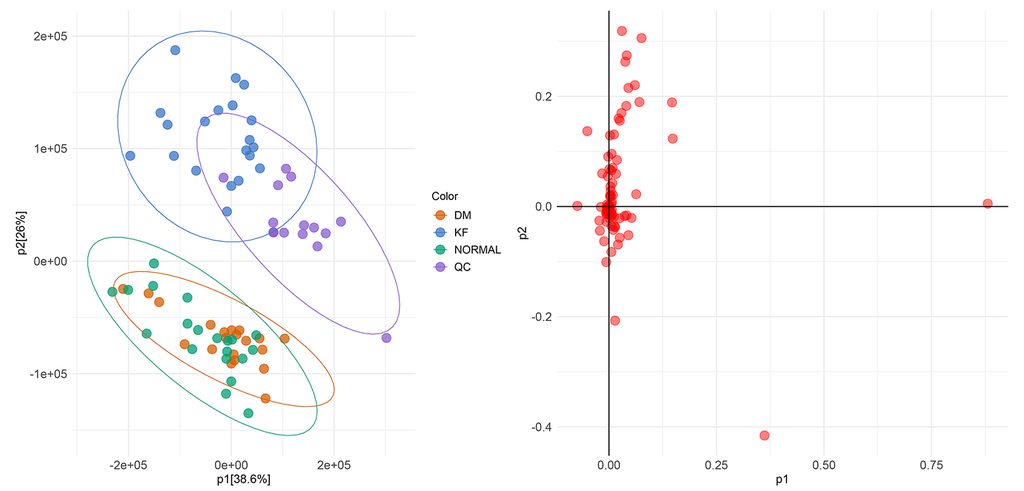

*Figure 5. PCA score and loading plots*

#### Try PLS-DA

```
#Do PLS-DA
output_plsda = multiv_analyze(METBObj=output_sqrt, method="pls", scale="center")

#Score plot
multiv_scoreplot(METBObj=output_sqrt, score_data=output_plsda$score_val, pcx=output_plsda$model_summary$R2X[1], pcy=output_plsda$model_summary$R2X[2])

#Loading plot
multiv_loadingplot(loading_data=output_plsda$loading_val)

#Loding plot of PC1
multiv_loadingplot_bypc(loading_data=output_plsda$loading_val, pc=1)

#VIP plot (Top 10)
vip_filtered = sort(output_plsda$vip_val,decreasing=T)[1:10]
multiv_vipplot(vip_data=vip_filtered, plot_title="VIP")

#Combined VIP and loading plot
multiv_viploadingplot(vip_data=output_plsda$vip_val, loading_data=output_plsda$loading_val, plot_title="Combined plot")
```

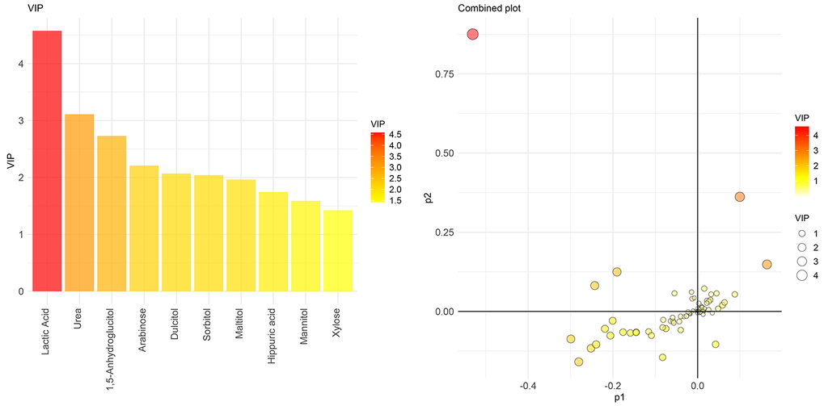

*Figure 6. VIP and combined plots*

With a given *user_input_obj*, users can use the following commands to perform OPLS-DA. OPLS-DA works similarly to PLS-DA but is limited to comparisons between two groups at a time.

```
#Do OPLS-DA
output_oplsda = multiv_analyze(METBObj=user_input_obj, method="opls", scale="center")
#Plots
multiv_scoreplot(METBObj=user_input_obj, score_data=output_oplsda$score_val, oscore_data=output_oplsda$oscore_val, pcx=output_oplsda$model_summary$R2X[1], pcy=output_oplsda$model_summary$R2X[2])

multiv_loadingplot(loading_data=output_oplsda$loading_val, oloading_data=output_oplsda$oloading_val)

multiv_vipplot(vip_data=output_oplsda$vip_val) #VIP plot
```

## Module 3-BIOMARKER ANALYSIS

Metabox 2.0 uses the [MUVR package](https://gitlab.com/CarlBrunius/MUVR) for biomarker analysis.

For this tutorial, download the [demo dataset](https://github.com/kwanjeeraw/metabox2/blob/main/inst/shiny/www/LC_Fat_Tissue.csv) (LC_Fat_Tissue.csv) and save it to your working directory. Then, run the following commands for biomarker analysis. The dataset contains 94 samples across two groups and 24 metabolites.

```
#Load input data
input_dat = read_input_data(filename='LC_Fat_Tissue.csv')

#Setup Metabox object and preview data
input_obj = set_input_obj(inputdata=input_dat, idCol=1, classCol=3, xCol=4)
head(input_obj$X) #preview the data
```

Specifying the required arguments for the *run_muvr* function:

- *METBObj*: Metabox object.
- *scale*: logical; scale variables to unit variance before PLS (default = FALSE).
- *nRep*: number of double cross-validation repetitions (default = 3).
- *varRatio*: proportion of variables in inner loops (default = 0.75).
- *partitionSize*: proportion of data for training (default = 0.7).
- *method*: ML method (PLS or RF; default = PLS).
- *DA*: logical for classification (default = TRUE); set FALSE for regression.
- *fitness*: evaluation metric; AUROC (default) or MISS for classification, RMSEP for regression.

```
#Biomarker analysis by PLS-DA
output_muvr = run_muvr(METBObj=input_obj, scale=TRUE, method="PLS")

#Get VIP ranks
MUVR_getvip(output_muvr)

#VIP rank plot
MUVR_plotvip(output_muvr)

#Performance plot
MUVR_plotval(output_muvr)
```

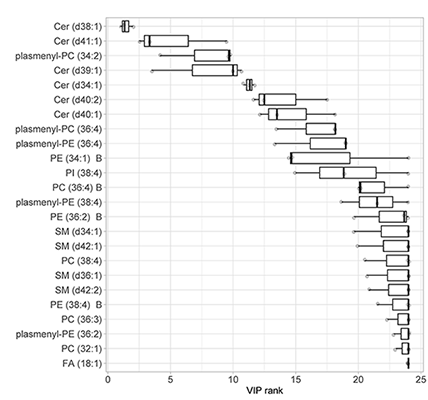

*Figure 7. VIP plot*

## Module 4-INTEGRATIVE ANALYSIS

Metabox 2.0 uses the [packMBPLSDA](https://cran.r-project.org/web/packages/packMBPLSDA/index.html) for integrative analysis.

For this tutorial, download the [LC dataset](https://github.com/kwanjeeraw/metabox2/blob/main/inst/shiny/www/LC_Fat_Tissue.csv) (LC_Fat_Tissue.csv) and the [GC dataset](https://github.com/kwanjeeraw/metabox2/blob/main/inst/shiny/www/GC_Fat_Tissue.csv) (GC_Fat_Tissue.csv), and save them to your working directory. Integrative analysis requires at least two datasets from the same subjects measured on different platforms. Then, run the following commands for integrative analysis. Each dataset contains 94 samples, including 24 LC metabolites and 137 GC metabolites.

```
#Load two input datasets
input_LC = read_input_data(filename='LC_Fat_Tissue.csv') #load input file1
input_GC = read_input_data(filename='GC_Fat_Tissue.csv') #load input file2

#Setup Metabox objects and preview data
obj_LC = set_input_obj(inputdata=input_LC, idCol=1, classCol=3, xCol=4)
obj_GC = set_input_obj(inputdata=input_GC, idCol=1, classCol=3, xCol=4)
head(obj_LC$X) #preview the data1
```

Specifying the required arguments for the *mbplsda_analyze* function:

- *class_data*: one-column data frame of class/category data.
- *input_data*: list of dataframes containing two or more datasets of explanatory (independent) variables. must have the same samples and no duplicated variables.
- *scale*: logical; whether to standardize variables.
- *option*: block weighting method: none (default) or uniform.
- *nf*: number of principal components (default = 10).
- *optdim*: optimal number of components (default = 2).
- *nrepet*: number of cross-validation repetitions.
- *npermut*: number of permutations.
- *nboot*: number of bootstrap replications.
- *threshold*: numeric value between 0 and 1 indicating the prediction threshold (default = 0.5).
- *testmodel*: logical value indicating whether to perform model component testing and permutation (default = FALSE).
- *cpus*: number of CPUs for parallel computing.

```
#Integrative analysis by MBPLSDA
output_mbpls = mbplsda_analyze(class_data=data.frame(obj_LC$Y), input_data=list(lc = obj_LC$X,gc = obj_GC$X), nrepet=10, npermut=5, nboot=5, testmodel=TRUE, cpus=1)

#Block importance plot
mbplsda_plotboot_bipc(output_mbpls$result$res_boot)

#Variable importance plot
mbplsda_plotboot_vipc(output_mbpls$result$res_boot)

#Prediction error rate plot
mbplsda_plottestdim(output_mbpls$result$res_optimal)

#Permutation testing plot
mbplsda_plotpermut(output_mbpls$result$res_permut)

#Scree plot
mbplsda_screeplot(output_mbpls$result$base_model$eig)
```

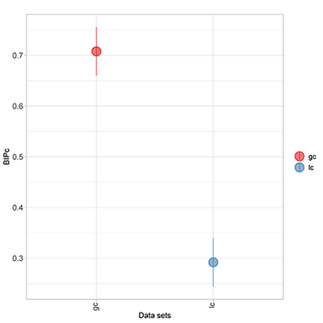

*Figure 8. Block importance plot*

## Module 5-DATA INTERPRETATION

Metabox 2.0 provides data interpretation in a pathway context for genes, proteins, and metabolites, as well as chemical class context for metabolites.

For this tutorial, download the [demo dataset](https://github.com/kwanjeeraw/metabox2/blob/main/inst/shiny/www/metabolite_list.csv) (metabolite_list.csv) and save it to your working directory. It is assumed that users already have a list of metabolites and associated statistical information, as shown in the demo dataset.

#### Try overrepresentation analysis (ORA)

Pathway overrepresentation analysis will be performed on a given list of metabolites using the KEGG database as the pathway resource, while chemical class overrepresentation analysis will be performed using the HMDB database as the metabolite resource.

Specifying the required arguments for the *overrep_analyze* function:

- *txtinput*: character vector of feature IDs (e.g., c(“C12078”, “C02273”)). For pathway analysis uses KEGG IDs (e.g., C12078) for compounds, UniProt entries (e.g., P0C9J6) for proteins, and NCBI Gene IDs (e.g., 10327) for genes. For chemical class analysis uses HMDB IDs (e.g., HMDB0000001) for compounds.
- *nodetype*: node type: compound (default), protein, or gene.
- *settype*: set type: pathway (default) or chemicalclass.
- *organism*: KEGG organism code; not used if `settype = "chemicalclass"` (default = hsa; or tdc).
- *size*: minimum number of members per term (default = 3).
- *universe*: background feature IDs (default = all unique IDs in the set collection).

```
#Load input file
input_dat = read_input_data(filename='metabolite_list.csv')

#Do pathway ORA
output_ora = overrep_analyze(txtinput=input_dat$kegg, nodetype="compound", size=5)
head(output_ora$enrichment) #preview result

#Do chemical class ORA
output_chem = overrep_analyze(txtinput=input_dat$hmdb, settype="chemicalclass")
head(output_chem$enrichment) #preview result

#Export result
write.csv(output_chem$enrichment,file="ora.csv",row.names=FALSE)
```

#### Try pathway enrichment analysis

Pathway enrichment analysis will be performed on a given list of metabolites, incorporating statistical values (e.g., p-, t-, or F-values) and optional directionality (e.g., fold changes), using the KEGG database as the pathway resource.

Specifying the required arguments for the *enrichment_analyze* function:

- *input_data*: dataframe containing feature IDs, statistics (e.g., p-, t-, or F-values), and optional directions (e.g., fold changes).
- *pcol*: column index for statistical values (default = 2).
- *fcol*: column index for direction values (e.g., fold changes; default = NULL, directionality ignored).
- *method*: enrichment method: reporter (default), fisher, median, mean, stouffer.
- *nodetype*: node type: compound (default), protein, or gene.
- *settype*: set type: pathway (default) or chemicalclass.
- *organism*: KEGG organism code; not used if `settype = "chemicalclass"` (default = hsa; or tdc).
- *size*: minimum number of members per term (default = 3).

```
#Load input file
input_dat = read_input_data(filename='metabolite_list.csv')

#Enrichment analysis containing directional values (Fold-change)
output_enr = enrichment_analyze(input_data=input_dat, pcol=5, fccol=6, method="reporter", nodetype="compound", settype="pathway")
head(output_enr$enrichment) #preview result

#Export result
write.csv(output_enr$enrichment,file="enrichment.csv",row.names=FALSE)
```